# ETC5512: Solutions for Lab 7

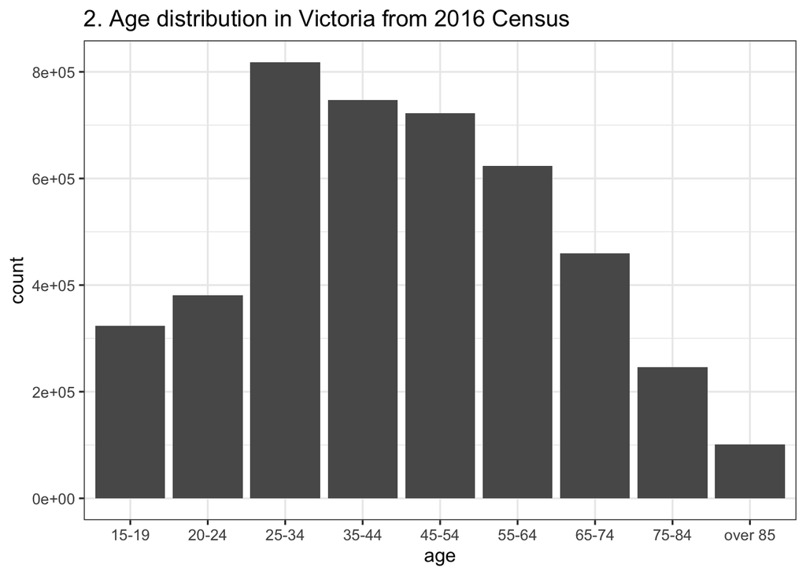

```r
STE_G17_tidy2_df %>%
   group_by(age) %>%
   summarise(count = sum(count)) %>%
   ggplot() +
      geom_col(aes(x = age, y = count)) +
      ggtitle("2. Age distribution in Victoria from 2016 Census") +
      theme_bw(base_size = 12)
```

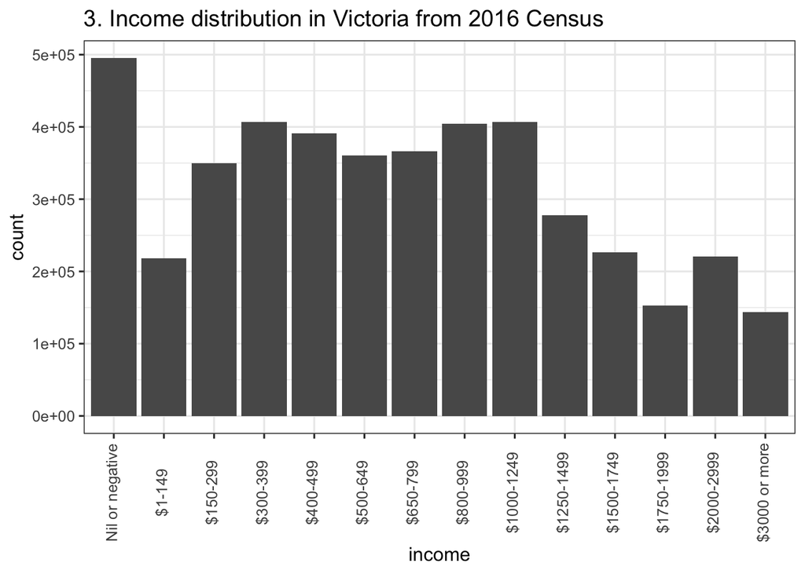

```r
STE_G17_tidy2_df %>%
   group_by(income) %>%
   summarise(count = sum(count)) %>%
   ggplot() +
      geom_col(aes(x = income, y = count)) +
      ggtitle("3. Income distribution in Victoria from 2016 Census") +
      theme_bw(base_size = 12) +
      theme(axis.text.x = element_text(angle = 90, vjust = 0.3))
```

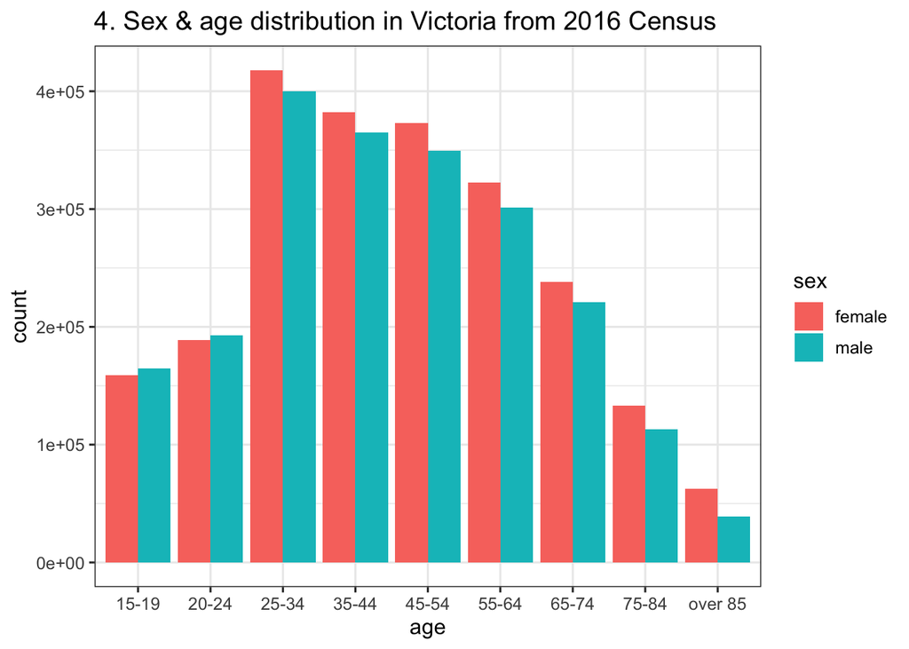

```r
STE_G17_tidy2_df %>%
   group_by(sex, age) %>%
   summarise(count = sum(count)) %>%
   ggplot() +
      geom_col(aes(x = age, y = count, fill = sex), position = "dodge") +
      ggtitle("4. Sex & age distribution in Victoria from 2016 Census") +
      theme_bw(base_size = 12)
```

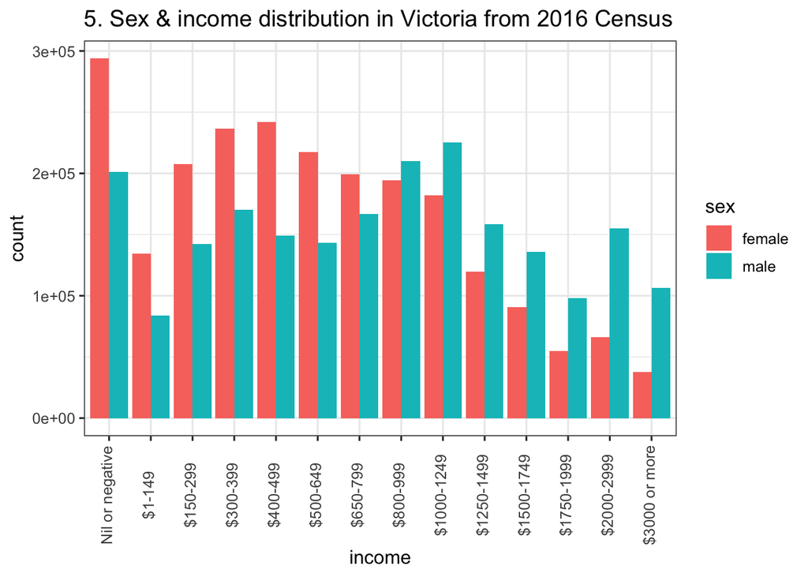

```r
STE_G17_tidy2_df %>%
   group_by(sex, income) %>%
   summarise(count = sum(count)) %>%
   ggplot() +
      geom_col(aes(x = income, y = count, fill = sex), position = "dodge") +
      ggtitle("5. Sex & income distribution in Victoria from 2016 Census") +
      theme_bw(base_size = 12) +
      theme(axis.text.x = element_text(angle = 90, vjust = 0.3))
```

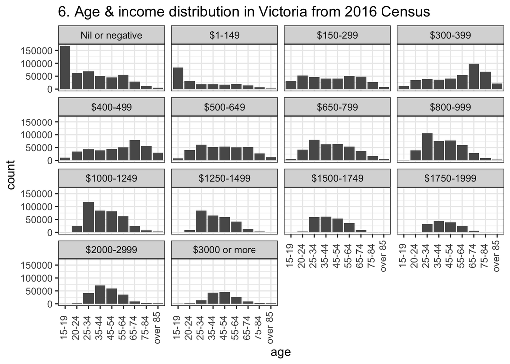

```r
STE_G17_tidy2_df %>%
   group_by(age, income) %>%
   summarise(count = sum(count)) %>%
   ggplot() +
      geom_col(aes(x = age, y = count), position = "dodge") +
      facet_wrap(~income) +
      ggtitle("6. Age & income distribution in Victoria from 2016 Census") +
      theme_bw(base_size = 12) +
      theme(axis.text.x = element_text(angle = 90, vjust = 0.3))
```

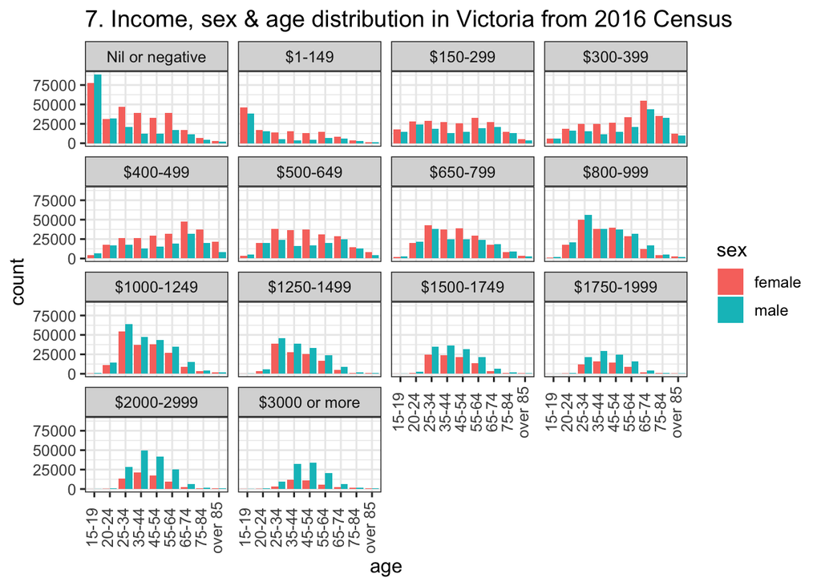

```r
STE_G17_tidy2_df %>%
   ggplot(aes(x = age, y = count, fill = sex)) +
      geom_col(position = "dodge") +
   facet_wrap(~income) +
   theme_bw(base_size = 12) +
   theme(axis.text.x = element_text(angle = 90, vjust = 0.3)) +
   ggtitle("7. Income, sex & age distribution in Victoria from 2016 Census")
```

## 💃 Exercise 7C

We will use the STE data to extract the relevant statistics.

```r
n_women_15_54 <- STE_G17_tidy_df %>%
   filter(age_min >=15 & age_max <= 54 & sex == "female") %>%
   pull(count) %>%
   sum()

n_vic <- 5926624 # This number needs to be extracted from https://quickstats.censusdata.abs.gov.au/census_services/getproduct/census/2016/quickstat/2?opendocument

n_people_25_34_earn_1750_or_more <-  STE_G17_tidy_df %>%
   filter(age_min >=25 & age_max <= 34 & sex == "both" & income_min >= 1750) %>%
   pull(count) %>%
   sum()

n_man_25_44 <-  STE_G17_tidy_df %>%
   filter(age_min >=25 & age_max <= 44 & sex == "male") %>%
   pull(count) %>%
   sum()

n_man_25_44_earn_1500_or_less <-  STE_G17_tidy_df %>%
   filter(age_min >=25 & age_max <= 44 & sex == "male" & income_max <= 1500) %>%
   pull(count) %>%
   sum()
```

According to the 2016 Census data:

- There are 1,520,073 women in Victoria are aged between 15-54 years old.
- The proportion of people in Victoria that are 25-34 years old (inclusive) and earn $1750 or more per week is 0.0149355.
- If I randomly select a man from all the man aged 25-44 years old in Victoria, the probability that the man I selected earns less than $1500 per week is 0.684063.

## 🤺 Exercise 7D

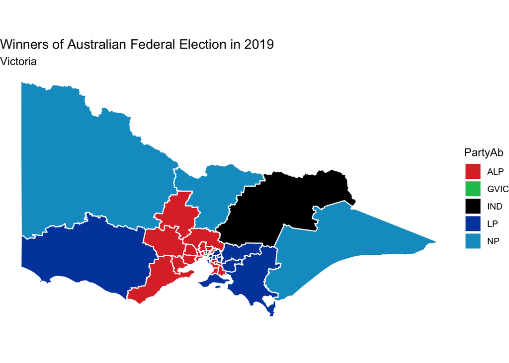

```r
election_2019_df <- read_csv(here::here("data/HouseDopByDivisionDownload-24310.csv"),
                        skip = 1, # first row is meta data
                        # below *explicitly* defines the column types
                        # note e.g. DivisionID is normally read as numeric
                        # but we specify it should be read as character
                        col_types = cols(
                             StateAb = col_character(),
                             DivisionID = col_character(),
                             DivisionNm = col_character(),
                             CountNumber = col_double(),
                             BallotPosition = col_character(),
                             CandidateID = col_character(),
                             Surname = col_character(),
                             GivenNm = col_character(),
                             PartyAb = col_character(),
                             PartyNm = col_character(),
                             Elected = col_character(),
                             HistoricElected = col_character(),
                             CalculationType = col_character(),
                             CalculationValue = col_double())) %>%
   # select winning candidate only
   filter(CalculationType == "Preference Count" &
             Elected == "Y" &
             CountNumber == 0) %>%
   # make division name upper case so
   # it can be joined later with map data
   mutate(elect_div = toupper(DivisionNm)) %>%
   # select only the variables needed
   select(elect_div, PartyAb)

# map data from the eechidna package
nat_map19 <- nat_map_download(2019)

# define the political colors (feel free to change)
party_colors <- c("ALP" = "#DE3533", "LNP" = "#ADD8E6",
                  "KAP" = "#8B0000", "GRN" = "#10C25B",
                  "GVIC" = "#10C25B", "XEN" = "#ff6300",
                  "LP" = "#0047AB", "NP" = "#0a9cca",
                  "IND" = "#000000")

vic_map19 <- nat_map19 %>%
   filter(state == "VIC") %>%
   left_join(election_2019_df, by = "elect_div")
```

## 🏂 Exercise 7E

**Integrate data from different sources**

```r
# loads the variable `centroids_sa1_2016` with the centroids of SA1 for 2016 census
load(url("https://github.com/ropenscilabs/eechidna/raw/master/extra-data/centroids_sa1_2016.rda"))
# change to a tidy data frame
centroids_sa1_2016_df <- centroids_sa1_2016$data %>%
  mutate(long = centroids_sa1_2016$centroids@coords[, 1],
         lat  = centroids_sa1_2016$centroids@coords[, 2])
```

```r
skimr::skim(centroids_sa1_2016_df)
```

Data summary

| Name | centroids_sa1_2016_df |
| --- | --- |
| Number of rows | 57490 |
| Number of columns | 7 |
| _______________________ |  |
| Column type frequency: |  |
| factor | 4 |
| numeric | 3 |
| ________________________ |  |
| Group variables | None |

**Variable type: factor**

| skim_variable | n_missing | complete_rate | ordered | n_unique | top_counts |
| --- | --- | --- | --- | --- | --- |
| SA1_7DIGIT | 0 | 1 | FALSE | 57490 | 110: 1, 110: 1, 110: 1, 110: 1 |
| SA1_MAIN16 | 0 | 1 | FALSE | 57490 | 101: 1, 101: 1, 101: 1, 101: 1 |
| STATE_CODE | 0 | 1 | FALSE | 9 | 1: 18395, 2: 14069, 3: 11559, 5: 5980 |
| STATE_NAME | 0 | 1 | FALSE | 9 | New: 18395, Vic: 14069, Que: 11559, Wes: 5980 |

**Variable type: numeric**

| skim_variable | n_missing | complete_rate | mean | sd | p0 | p25 | p50 | p75 | p100 | hist |
| --- | --- | --- | --- | --- | --- | --- | --- | --- | --- | --- |
| AREA_SQKM | 0 | 1 | 133.73 | 3151.45 | 0.00 | 0.13 | 0.21 | 0.58 | 328260.50 | ▇▁▁▁▁ |
| long | 0 | 1 | 144.74 | 10.67 | 96.83 | 144.76 | 148.00 | 151.22 | 167.98 | ▁▁▁▇▁ |
| lat | 0 | 1 | -32.87 | 5.14 | -43.44 | -36.87 | -33.86 | -31.00 | -9.27 | ▅▇▃▁▁ |

```r
# get an indicator
ind <- mgcv::in.out(as.matrix(select(vic_map19, long, lat)),
                    as.matrix(select(centroids_sa1_2016_df, long, lat)))
centroids_vic_sa1_2016_df <- centroids_sa1_2016_df %>%
   filter(ind) %>%
   # change SA1_7DIGIT to numeric from factor
   # so columns can be joined later
   mutate(SA1_7DIGIT = as.numeric(as.character(SA1_7DIGIT)))
```

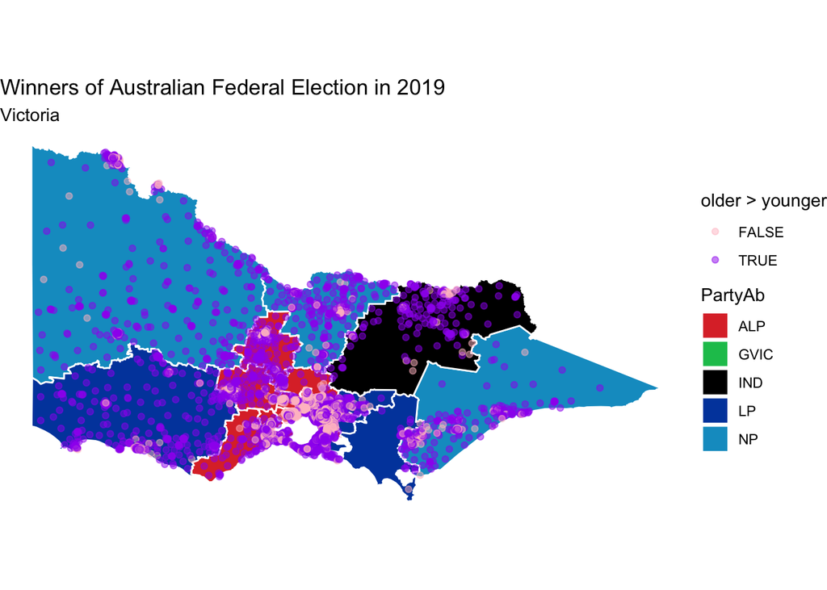

```r
aggregate_df <- SA1_G17_tidy_df %>%
   mutate(older = ifelse(age_min >= 45, "older", "younger")) %>%
   filter(sex == "both") %>%
   group_by(SA1_7DIGITCODE_2016, older) %>%
   summarise(count = sum(count)) %>%
   pivot_wider(SA1_7DIGITCODE_2016, names_from = older, values_from = count) %>%
   right_join(centroids_vic_sa1_2016_df, c("SA1_7DIGITCODE_2016"="SA1_7DIGIT"))

plot_vic_map19 +
   geom_point(data = aggregate_df,
              aes(x = long, y = lat, color = older > younger),
              alpha = 1/2) +
   scale_color_manual(values = c("TRUE" = "purple", "FALSE" = "pink"))
```

The regional areas have an older population. This could be because tertiary education and certain career opportunites are only available in urban areas. There indeed seems to be more younger people around the inner city but as there are too many points in the location, it requires more careful examination.